# Analysis

Zach

2024-02-06

# Analysis

Within this script will be the analyses for the study about ordering preferences in LLMs.

We care about how the effects of generative preferences and observed (relative) frequency change as a function of the overall frequency of the binomial.

This script will be divided into two main sections:

1. The analyses for just the binomial (*cat and dog*)
2. The analyses for the binomial within a sentence context*.*

We will run analyses for reading times and 2afc task. 2afc task is operationalized here as the sum of the log probabilities across all words in the sentence. Reading time is operationalized as the sum of the log probabilities across our target region, consists of 6 words: the first word in the binomial to the 6th word after.

## Just Binomials

### 2afc

Technically, for just binomials, 2afc = reading times. Since 2afc is the probability of the sentence (sum of log probs for each item in the sentence), and reading times are the probability of a specific region in the sentence (sum of log probs for each item in a given region of the sentence).

In this case, the entire sentence is the region we care about. Thus for just binomials we run only one task for each language model.

Our main analyses will be:

$$logit(P_{AandB}) \sim GenPref + OrderingPref + Overall Freq +
OverallFreq \colon GenPref + OverallFreq \colon OrderingPref$$

Where our dependent variable is the probability of the binomial being alphabetical form.

And the independent variables are the generative preference of a given binomial, the ordering preference, the overall frequency, and the interaction between overall frequency and generative preference as well as the interaction between overall frequency and the ordering preference.

We don’t need a random intercept for item because we have one observation for each item, so this would be meaningless.

We also don’t need a random intercept for “subject” because we don’t have any subjects.

#### GPT2

Load data:

```r
gpt2_data_just_binoms = read_csv('../Data/gpt2_2afc_binom_ordering_prefs.csv') %>%
  separate(binom, c('WordA', 'and', 'WordB'), remove = F, sep = ' ') %>%
  select(-and) %>%
  left_join(corpus) %>%
  mutate(log_freq = log(OverallFreq)) %>%
  mutate(OverallFreq = log_freq - mean(log_freq)) %>%
  mutate(GenPref = GenPref - 0.5) %>%
  mutate(RelFreq = RelFreq - 0.5)
```

Quick and dirty historgram:

```r
# ggplot(data = gpt2_data_just_binoms, aes(x=ProbAandB, y = ..density..)) +
#   geom_histogram() +
#   theme_bw()
#
# ggplot(data = gpt2xl_data_just_binoms, aes(x=ProbAandB, y = ..density..)) +
#   geom_histogram() +
#   theme_bw()
#
# ggplot(data = llama7b_data_just_binoms, aes(x=ProbAandB, y = ..density..)) +
#   geom_histogram() +
#   theme_bw()
#
# ggplot(data = llama13b_data_just_binoms, aes(x=ProbAandB, y = ..density..)) +
#   geom_histogram() +
#   theme_bw()
#
# ggplot(data = corpus, aes(x=RelFreq, y = ..density..)) +
#   geom_histogram() +
#   theme_bw()
```

Analysis:

```r
prior_probs = c(
  prior(student_t(3, 0, 1), class = 'Intercept'),
  prior(student_t(3, 0, 1), class = 'sigma'),
  prior(student_t(3, 0, 1), class = 'b')
)

options(contrasts = c("contr.sum","contr.sum"))

gpt2_2afc_model_just_binoms = brm(data = gpt2_data_just_binoms,
                       log_odds ~ GenPref + RelFreq + GenPref:OverallFreq + RelFreq:OverallFreq + OverallFreq,
                       prior = prior_probs,
                       iter = 20000,
                       chains = 4,
                       cores = 4,
                       #control = list(adapt_delta=0.99, max_treedepth = 15),
                       control = list(max_treedepth = 20),
                       file = '../Data/gpt2_2afc_model_just_binoms'
                      )

fixef(gpt2_2afc_model_just_binoms)
```

```
##                        Estimate  Est.Error       Q2.5      Q97.5
## Intercept           -0.10298070 0.10220599 -0.3027986 0.09677190
## GenPref             -0.51645486 0.63807773 -1.8133454 0.69278918
## RelFreq              4.61991132 0.49629235  3.6549439 5.58736193
## OverallFreq         -0.04089967 0.05474039 -0.1494468 0.06579369
## GenPref:OverallFreq  0.09475182 0.38904484 -0.6631821 0.85991102
## RelFreq:OverallFreq  0.95972475 0.23658268  0.4940506 1.42669367
```

```r
# mcmc_plot(
#   gpt2_2afc_model_just_binoms,
#   type = 'pairs',
#   off_diag_fun = 'hex',
#   diag_fun = 'dens',
#   fixed = T
# )
```

Checking posterior samples:

```r
post_samples_gpt2 = as.data.frame(fixef(gpt2_2afc_model_just_binoms, summary = F))

post_samples_genpref = sum(post_samples_gpt2$GenPref < 0) / length(post_samples_gpt2$GenPref)

post_samples_genpref_freq = sum(post_samples_gpt2$`GenPref:OverallFreq` < 0) / length(post_samples_gpt2$`GenPref:OverallFreq`)

print(post_samples_genpref)
```

```
## [1] 0.7937
```

```r
print(post_samples_genpref_freq)
```

```
## [1] 0.403725
```

#### GPT2-XL

Load data:

```r
gpt2xl_data_just_binoms = read_csv('../Data/gpt2xl_2afc_binom_ordering_prefs.csv') %>%
  separate(binom, c('WordA', 'and', 'WordB'), remove = F, sep = ' ') %>%
  select(-and) %>%
  left_join(corpus) %>%
  mutate(log_freq = log(OverallFreq)) %>%
  mutate(OverallFreq = log_freq - mean(log_freq)) %>%
  mutate(GenPref = GenPref - 0.5) %>%
  mutate(RelFreq = RelFreq - 0.5)
```

Analysis:

```r
options(contrasts = c("contr.sum","contr.sum"))

gpt2xl_2afc_model_just_binoms = brm(data = gpt2xl_data_just_binoms,
                       log_odds ~ GenPref + RelFreq + GenPref:OverallFreq + RelFreq:OverallFreq + OverallFreq,
                       prior = prior_probs,
                       iter = 20000,
                       chains = 4,
                       cores = 4,
                       #control = list(adapt_delta=0.99, max_treedepth = 15),
                       control = list(max_treedepth = 20),
                       file = '../Data/gpt2xl_2afc_model_just_binoms'
                      )

fixef(gpt2xl_2afc_model_just_binoms)
```

```
##                        Estimate  Est.Error       Q2.5      Q97.5
## Intercept            0.04859944 0.09068049 -0.1291911 0.22552551
## GenPref             -0.88513829 0.62749346 -2.1659214 0.29410511
## RelFreq              5.33855478 0.45529829  4.4543698 6.24557220
## OverallFreq         -0.01031684 0.04936225 -0.1073811 0.08602887
## GenPref:OverallFreq -0.17367092 0.35462229 -0.8731418 0.52492911
## RelFreq:OverallFreq  1.01127545 0.21305908  0.5924345 1.42794639
```

Checking posterior samples for some of the effects:

```r
post_samples_gpt2xl = as.data.frame(fixef(gpt2xl_2afc_model_just_binoms, summary = F))

post_samples_genpref = sum(post_samples_gpt2xl$GenPref < 0) / length(post_samples_gpt2xl$GenPref)

post_samples_genpref_freq = sum(post_samples_gpt2xl$`GenPref:OverallFreq` < 0) / length(post_samples_gpt2xl$`GenPref:OverallFreq`)

# post_samples_relfreq_freq = sum(post_samples_gpt2$`RelFreq:OverallFreq` > 0) / length(post_samples_gpt2$`RelFreq:OverallFreq`)

print(post_samples_genpref)
```

```
## [1] 0.92675
```

```r
print(post_samples_genpref_freq)
```

```
## [1] 0.68625
```

#### Llama-7b

Load data:

```r
llama7b_data_just_binoms = read_csv('../Data/llama7b_2afc_binom_ordering_prefs.csv') %>%
  separate(binom, c('WordA', 'and', 'WordB'), remove = F, sep = ' ') %>%
  select(-and) %>%
  left_join(corpus) %>%
  mutate(log_freq = log(OverallFreq)) %>%
  mutate(OverallFreq = log_freq - mean(log_freq)) %>%
  mutate(GenPref = GenPref - 0.5) %>%
  mutate(RelFreq = RelFreq - 0.5)
```

Analysis:

```r
options(contrasts = c("contr.sum","contr.sum"))

llama7b_2afc_model_just_binoms = brm(data = llama7b_data_just_binoms,
                       log_odds ~ GenPref + RelFreq + GenPref:OverallFreq + RelFreq:OverallFreq + OverallFreq,
                       prior = prior_probs,
                       iter = 20000,
                       chains = 4,
                       cores = 4,
                       #control = list(adapt_delta=0.99, max_treedepth = 15),
                       control = list(max_treedepth = 20),
                       file = '../Data/llama7b_2afc_model_just_binoms'
                      )

fixef(llama7b_2afc_model_just_binoms)
```

```
##                        Estimate  Est.Error        Q2.5     Q97.5
## Intercept            0.22253377 0.12733636 -0.02736596 0.4710400
## GenPref              1.11174970 0.84225439 -0.40131032 2.9061028
## RelFreq              3.07299347 0.64067325  1.80776804 4.3098748
## OverallFreq          0.03501128 0.06869637 -0.10033830 0.1697770
## GenPref:OverallFreq -0.31521706 0.46939963 -1.24428256 0.5894812
## RelFreq:OverallFreq  0.22575661 0.28328049 -0.33009827 0.7782798
```

Checking posterior:

```r
post_samples_llama7b = as.data.frame(fixef(llama7b_2afc_model_just_binoms, summary = F))

post_samples_genpref = sum(post_samples_llama7b$GenPref < 0) / length(post_samples_llama7b$GenPref)

post_samples_genpref_freq = sum(post_samples_llama7b$`GenPref:OverallFreq` < 0) / length(post_samples_llama7b$`GenPref:OverallFreq`)

post_samples_relfreq_freq = sum(post_samples_llama7b$`RelFreq:OverallFreq` < 0) / length(post_samples_llama7b$`RelFreq:OverallFreq`)

print(post_samples_genpref)
```

```
## [1] 0.081425
```

```r
print(post_samples_genpref_freq)
```

```
## [1] 0.74795
```

```r
print(post_samples_relfreq_freq)
```

```
## [1] 0.2141
```

#### Llama-13b

Load data:

```r
llama13b_data_just_binoms = read_csv('../Data/llama13b_2afc_binom_ordering_prefs.csv') %>%
  separate(binom, c('WordA', 'and', 'WordB'), remove = F, sep = ' ') %>%
  select(-and)
llama13b_data_just_binoms = llama13b_data_just_binoms %>%
  mutate(WordA = tolower(WordA), WordB = tolower(WordB))

llama13b_data_just_binoms = llama13b_data_just_binoms %>%
  left_join(corpus) %>%
  mutate(log_freq = log(OverallFreq)) %>%
  mutate(OverallFreq = log_freq - mean(log_freq)) %>%
  mutate(GenPref = GenPref - 0.5) %>%
  mutate(RelFreq = RelFreq - 0.5) %>%
  mutate(gen_rel_diff = GenPref - RelFreq)
```

Analysis:

```r
options(contrasts = c("contr.sum","contr.sum"))
llama13b_2afc_model_just_binoms = brm(data = llama13b_data_just_binoms,
                       log_odds ~ GenPref + RelFreq + GenPref:OverallFreq + RelFreq:OverallFreq + OverallFreq,
                       prior = prior_probs,
                       iter = 20000,
                       chains = 4,
                       cores = 4,
                       #control = list(adapt_delta=0.99, max_treedepth = 15),
                       control = list(max_treedepth = 20),
                       file = '../Data/llama13b_2afc_model_just_binoms'
                      )

fixef(llama13b_2afc_model_just_binoms)
```

```
##                          Estimate Est.Error       Q2.5      Q97.5
## Intercept            0.0141775838 0.2146310 -0.4097275  0.4341265
## GenPref              5.5733370166 2.0035168  1.5348565  9.3198150
## RelFreq              2.5088235666 1.2232636  0.3337739  5.0431647
## OverallFreq         -0.0006989114 0.1165629 -0.2292811  0.2277113
## GenPref:OverallFreq -2.0062067745 0.8625444 -3.7481002 -0.4052961
## RelFreq:OverallFreq -0.3615401867 0.4695830 -1.2959748  0.5494842
```

Checking posterior:

```r
post_samples_llama13b = as.data.frame(fixef(llama13b_2afc_model_just_binoms, summary = F))

# post_samples_genpref = sum(post_samples_llama13b$GenPref < 0) / length(post_samples_llama13b$GenPref)

post_samples_genpref_freq = sum(post_samples_llama13b$`GenPref:OverallFreq` < 0) / length(post_samples_llama13b$`GenPref:OverallFreq`)

post_samples_relfreq_freq = sum(post_samples_llama13b$`RelFreq:OverallFreq` < 0) / length(post_samples_llama13b$`RelFreq:OverallFreq`)

print(post_samples_genpref_freq)
```

```
## [1] 0.994175
```

```r
print(post_samples_relfreq_freq)
```

```
## [1] 0.780025
```

#### Llama3 8b

Load data:

```r
llama3_8b_data_just_binoms = read_csv('../Data/llama3_8b_2afc_binom_ordering_prefs.csv') %>%
  separate(binom, c('WordA', 'and', 'WordB'), remove = F, sep = ' ') %>%
  select(-and)
llama3_8b_data_just_binoms = llama3_8b_data_just_binoms %>%
  mutate(WordA = tolower(WordA), WordB = tolower(WordB))

llama3_8b_data_just_binoms = llama3_8b_data_just_binoms %>%
  left_join(corpus) %>%
  mutate(log_freq = log(OverallFreq)) %>%
  mutate(OverallFreq = log_freq - mean(log_freq)) %>%
  mutate(GenPref = GenPref - 0.5) %>%
  mutate(RelFreq = RelFreq - 0.5)
```

Analysis:

```r
options(contrasts = c("contr.sum","contr.sum"))
llama3_8b_2afc_model_just_binoms = brm(data = llama3_8b_data_just_binoms,
                       log_odds ~ GenPref + RelFreq + GenPref:OverallFreq + RelFreq:OverallFreq + OverallFreq,
                       prior = prior_probs,
                       iter = 20000,
                       warmup = 10000,
                       chains = 4,
                       cores = 4,
                       #control = list(adapt_delta=0.99, max_treedepth = 15),
                       control = list(max_treedepth = 20),
                       file = '../Data/llama3_8b_2afc_model_just_binoms'
                      )

fixef(llama3_8b_2afc_model_just_binoms)
```

```
##                        Estimate  Est.Error        Q2.5      Q97.5
## Intercept            0.14882851 0.09333245 -0.03324123 0.33272015
## GenPref              0.23516964 0.58926235 -0.90552989 1.40511691
## RelFreq              5.64112880 0.45516561  4.73776777 6.52930458
## OverallFreq         -0.07062223 0.04953657 -0.16835913 0.02647007
## GenPref:OverallFreq  0.06915016 0.35808051 -0.62802799 0.78087790
## RelFreq:OverallFreq  0.60760011 0.21630362  0.18381298 1.03284417
```

```r
llama3_8b_2afc_model_only_genpref = brm(data = llama3_8b_data_just_binoms,
                       log_odds ~ GenPref,
                       prior = prior_probs,
                       iter = 20000,
                       chains = 4,
                       cores = 4,
                       #control = list(adapt_delta=0.99, max_treedepth = 15),
                       control = list(max_treedepth = 20),
                       file = '../Data/llama3_8b_2afc_model_only_genpref'
                      )

fixef(llama3_8b_2afc_model_only_genpref)
```

```
##            Estimate Est.Error        Q2.5     Q97.5
## Intercept 0.1661612 0.1076925 -0.04455168 0.3747224
## GenPref   6.3002829 0.6702271  4.97287034 7.6238773
```

```r
llama3_simple_model = brm(data = llama3_8b_data_just_binoms,
                       log_odds ~ GenPref + RelFreq,
                       prior = prior_probs,
                       iter = 20000,
                       warmup = 10000,
                       chains = 4,
                       cores = 4,
                       #control = list(adapt_delta=0.99, max_treedepth = 15),
                       control = list(max_treedepth = 20),
                       file = '../Data/llama3_8b_simple_model_just_binoms'
                      )

fixef(llama3_simple_model)
```

```
##            Estimate  Est.Error       Q2.5     Q97.5
## Intercept 0.1609882 0.09310969 -0.0221252 0.3435996
## GenPref   0.1579954 0.58826902 -0.9963987 1.3355417
## RelFreq   6.2304493 0.42522092  5.3958315 7.0613089
```

Checking posterior:

```r
post_samples_llama3_8b = as.data.frame(fixef(llama3_8b_2afc_model_just_binoms, summary = F))

# post_samples_genpref = sum(post_samples_llama13b$GenPref < 0) / length(post_samples_llama13b$GenPref)

post_samples_genpref_freq = sum(post_samples_llama3_8b$`GenPref:OverallFreq` < 0) / length(post_samples_llama3_8b$`GenPref:OverallFreq`)

post_samples_relfreq_freq = sum(post_samples_llama3_8b$`RelFreq:OverallFreq` < 0) / length(post_samples_llama3_8b$`RelFreq:OverallFreq`)

post_samples_genpref = sum(post_samples_llama3_8b$`GenPref` < 0) / length(post_samples_llama3_8b$`GenPref`)

print(post_samples_genpref_freq)
```

```
## [1] 0.424525
```

```r
print(post_samples_relfreq_freq)
```

```
## [1] 0.002575
```

```r
print(post_samples_genpref)
```

```
## [1] 0.344975
```

#### Lama2 70B

```r
llama2_70b_data_just_binoms = read_csv('../Data/llama70b_2afc_binom_ordering_prefs.csv') %>%
  separate(binom, c('WordA', 'and', 'WordB'), remove = F, sep = ' ') %>%
  select(-and)
llama2_70b_data_just_binoms = llama2_70b_data_just_binoms %>%
  mutate(WordA = tolower(WordA), WordB = tolower(WordB))

llama2_70b_data_just_binoms = llama2_70b_data_just_binoms %>%
  left_join(corpus) %>%
  mutate(log_freq = log(OverallFreq)) %>%
  mutate(OverallFreq = log_freq - mean(log_freq)) %>%
  mutate(GenPref = GenPref - 0.5) %>%
  mutate(RelFreq = RelFreq - 0.5)
options(contrasts = c("contr.sum","contr.sum"))
llama_70b_2afc_model_just_binoms = brm(data = llama2_70b_data_just_binoms,
                       log_odds ~ GenPref + RelFreq + GenPref:OverallFreq + RelFreq:OverallFreq + OverallFreq,
                       prior = prior_probs,
                       iter = 20000,
                       warmup = 10000,
                       chains = 4,
                       cores = 4,
                       #control = list(adapt_delta=0.99, max_treedepth = 15),
                       control = list(max_treedepth = 20),
                       file = '../Data/llama_70b_2afc_model_just_binoms'
                      )

fixef(llama_70b_2afc_model_just_binoms)
```

```
##                        Estimate  Est.Error        Q2.5       Q97.5
## Intercept            0.13066702 0.08317572 -0.03127935  0.29328551
## GenPref             -0.04992038 0.54482024 -1.12076978  1.02047023
## RelFreq              5.50844676 0.41692054  4.69448096  6.32904713
## OverallFreq         -0.10251173 0.04495669 -0.19026324 -0.01408547
## GenPref:OverallFreq  0.22532246 0.32888217 -0.41950803  0.87536822
## RelFreq:OverallFreq  0.73259346 0.19751853  0.34244441  1.12101148
```

```r
llama_70b_2afc_model_only_genpref = brm(data = llama2_70b_data_just_binoms,
                       log_odds ~ GenPref,
                       prior = prior_probs,
                       iter = 20000,
                       chains = 4,
                       cores = 4,
                       #control = list(adapt_delta=0.99, max_treedepth = 15),
                       control = list(max_treedepth = 20),
                       file = '../Data/llama_70b_2afc_model_only_genpref'
                      )

fixef(llama_70b_2afc_model_only_genpref)
```

```
##            Estimate Est.Error        Q2.5     Q97.5
## Intercept 0.1498794 0.1027176 -0.05110499 0.3508392
## GenPref   5.9281162 0.6302827  4.69510007 7.1620646
```

#### Lama3 70B

```r
llama3_70b_data_just_binoms = read_csv('../Data/llama3_70b_2afc_binom_ordering_prefs.csv') %>%
  separate(binom, c('WordA', 'and', 'WordB'), remove = F, sep = ' ') %>%
  select(-and)
llama3_70b_data_just_binoms = llama3_70b_data_just_binoms %>%
  mutate(WordA = tolower(WordA), WordB = tolower(WordB))

llama3_70b_data_just_binoms = llama3_70b_data_just_binoms %>%
  left_join(corpus) %>%
  mutate(log_freq = log(OverallFreq)) %>%
  mutate(OverallFreq = log_freq - mean(log_freq)) %>%
  mutate(GenPref = GenPref - 0.5) %>%
  mutate(RelFreq = RelFreq - 0.5)
options(contrasts = c("contr.sum","contr.sum"))
llama3_70b_2afc_model_just_binoms = brm(data = llama3_70b_data_just_binoms,
                       log_odds ~ GenPref + RelFreq + GenPref:OverallFreq + RelFreq:OverallFreq + OverallFreq,
                       prior = prior_probs,
                       iter = 20000,
                       warmup = 10000,
                       chains = 4,
                       cores = 4,
                       #control = list(adapt_delta=0.99, max_treedepth = 15),
                       control = list(max_treedepth = 20),
                       file = '../Data/llama3_70b_2afc_model_just_binoms'
                      )

fixef(llama3_70b_2afc_model_just_binoms)
```

```
##                        Estimate  Est.Error        Q2.5     Q97.5
## Intercept            0.17497232 0.07800631  0.02332231 0.3279957
## GenPref              0.52357407 0.53025068 -0.48475741 1.6010650
## RelFreq              4.95917167 0.39039692  4.19005145 5.7295125
## OverallFreq         -0.06107634 0.04162164 -0.14218346 0.0210185
## GenPref:OverallFreq -0.20495089 0.31208878 -0.81582231 0.4096967
## RelFreq:OverallFreq  1.02258736 0.18642573  0.65281490 1.3885381
```

```r
llama3_70b_2afc_model_only_genpref = brm(data = llama3_70b_data_just_binoms,
                       log_odds ~ GenPref,
                       prior = prior_probs,
                       iter = 20000,
                       chains = 4,
                       cores = 4,
                       #control = list(adapt_delta=0.99, max_treedepth = 15),
                       control = list(max_treedepth = 20),
                       file = '../Data/llama3_70b_2afc_model_only_genpref'
                      )

fixef(llama3_70b_2afc_model_only_genpref)
```

```
##            Estimate  Est.Error       Q2.5     Q97.5
## Intercept 0.2015797 0.09593359 0.01163528 0.3904293
## GenPref   6.2810727 0.58412502 5.13299335 7.4264699
```

```r
llama3_70B_simple_model = brm(data = llama3_70b_data_just_binoms,
                       log_odds ~ GenPref + RelFreq,
                       prior = prior_probs,
                       iter = 20000,
                       warmup = 10000,
                       chains = 4,
                       cores = 4,
                       #control = list(adapt_delta=0.99, max_treedepth = 15),
                       control = list(max_treedepth = 20),
                       file = '../Data/llama3_70b_simple_model_just_binoms'
                      )

fixef(llama3_70B_simple_model)
```

```
##            Estimate  Est.Error        Q2.5     Q97.5
## Intercept 0.1977840 0.08126935  0.03889398 0.3576426
## GenPref   0.4081322 0.54153553 -0.63546250 1.5063911
## RelFreq   5.8634845 0.37518400  5.12454128 6.5901194
```

Post-samples:

```r
post_samples_llama3_70b = as.data.frame(fixef(llama3_70b_2afc_model_just_binoms, summary = F))

# post_samples_genpref = sum(post_samples_llama13b$GenPref < 0) / length(post_samples_llama13b$GenPref)

post_samples_genpref_freq = sum(post_samples_llama3_70b$`GenPref:OverallFreq` < 0) / length(post_samples_llama3_70b$`GenPref:OverallFreq`)

post_samples_relfreq_freq = sum(post_samples_llama3_70b$`RelFreq:OverallFreq` < 0) / length(post_samples_llama3_70b$`RelFreq:OverallFreq`)

post_samples_genpref = sum(post_samples_llama3_70b$`GenPref` > 0) / length(post_samples_llama3_70b$`GenPref`)

print(post_samples_genpref_freq)
```

```
## [1] 0.742675
```

```r
print(post_samples_relfreq_freq)
```

```
## [1] 0
```

```r
print(post_samples_genpref)
```

```
## [1] 0.8421
```

#### Phi-3

Load data:

```r
phi3_data_just_binoms = read_csv('../Data/phi3_2afc_binom_ordering_prefs.csv') %>%
  separate(binom, c('WordA', 'and', 'WordB'), remove = F, sep = ' ') %>%
  select(-and)
phi3_data_just_binoms = phi3_data_just_binoms %>%
  mutate(WordA = tolower(WordA), WordB = tolower(WordB))

phi3_data_just_binoms = phi3_data_just_binoms %>%
  left_join(corpus) %>%
  mutate(log_freq = log(OverallFreq)) %>%
  mutate(OverallFreq = log_freq - mean(log_freq)) %>%
  mutate(GenPref = GenPref - 0.5) %>%
  mutate(RelFreq = RelFreq - 0.5)
```

Analysis:

```r
options(contrasts = c("contr.sum","contr.sum"))
phi3_2afc_model_just_binoms = brm(data = phi3_data_just_binoms,
                       log_odds ~ GenPref + RelFreq + GenPref:OverallFreq + RelFreq:OverallFreq + OverallFreq,
                       prior = prior_probs,
                       iter = 20000,
                       warmup = 10000,
                       chains = 4,
                       cores = 4,
                       #control = list(adapt_delta=0.99, max_treedepth = 15),
                       control = list(max_treedepth = 20),
                       file = '../Data/phi3_2afc_model_just_binoms'
                      )

fixef(phi3_2afc_model_just_binoms)
```

```
##                        Estimate  Est.Error       Q2.5      Q97.5
## Intercept            0.09788464 0.10790490 -0.1140307 0.30794811
## GenPref              0.15208015 0.65642233 -1.1167732 1.47404627
## RelFreq              4.62252096 0.53360426  3.5750765 5.65988568
## OverallFreq         -0.07743127 0.05771689 -0.1910964 0.03691797
## GenPref:OverallFreq  0.38669013 0.41116157 -0.4133639 1.20392660
## RelFreq:OverallFreq  0.83429133 0.25202647  0.3389859 1.32640443
```

Checking posterior:

```r
post_samples_phi3 = as.data.frame(fixef(phi3_2afc_model_just_binoms, summary = F))

# post_samples_genpref = sum(post_samples_llama13b$GenPref < 0) / length(post_samples_llama13b$GenPref)

post_samples_genpref_freq = sum(post_samples_phi3$`GenPref:OverallFreq` < 0) / length(post_samples_phi3$`GenPref:OverallFreq`)

post_samples_relfreq_freq = sum(post_samples_phi3$`RelFreq:OverallFreq` < 0) / length(post_samples_phi3$`RelFreq:OverallFreq`)

print(post_samples_genpref_freq)
```

```
## [1] 0.1729
```

```r
print(post_samples_relfreq_freq)
```

```
## [1] 4e-04
```

#### Yi 34b

```r
yi34b_data_just_binoms = read_csv('../Data/yi34b_2afc_binom_ordering_prefs.csv') %>%
  separate(binom, c('WordA', 'and', 'WordB'), remove = F, sep = ' ') %>%
  select(-and)
yi34b_data_just_binoms = yi34b_data_just_binoms %>%
  mutate(WordA = tolower(WordA), WordB = tolower(WordB))

yi34b_data_just_binoms = yi34b_data_just_binoms %>%
  left_join(corpus) %>%
  mutate(log_freq = log(OverallFreq)) %>%
  mutate(OverallFreq = log_freq - mean(log_freq)) %>%
  mutate(GenPref = GenPref - 0.5) %>%
  mutate(RelFreq = RelFreq - 0.5)
```

Analysis:

```r
options(contrasts = c("contr.sum","contr.sum"))
yi34b_2afc_model_just_binoms = brm(data = yi34b_data_just_binoms,
                       log_odds ~ GenPref + RelFreq + GenPref:OverallFreq + RelFreq:OverallFreq + OverallFreq,
                       prior = prior_probs,
                       iter = 20000,
                       warmup = 10000,
                       chains = 4,
                       cores = 4,
                       #control = list(adapt_delta=0.99, max_treedepth = 15),
                       control = list(max_treedepth = 20),
                       file = '../Data/yi34b_2afc_model_just_binoms'
                      )

fixef(yi34b_2afc_model_just_binoms)
```

```
##                        Estimate  Est.Error        Q2.5     Q97.5
## Intercept           -0.24140875 0.17558996 -0.58561093 0.1024724
## GenPref              1.89409251 1.29148225 -0.25050959 4.7413075
## RelFreq              5.01533086 0.94856955  3.07334066 6.8140126
## OverallFreq         -0.07547802 0.09486054 -0.26155316 0.1096920
## GenPref:OverallFreq  0.28001313 0.59241679 -0.86960506 1.4679919
## RelFreq:OverallFreq  0.82147111 0.38375514  0.07588537 1.5821934
```

```r
post_samples_yi34b = as.data.frame(fixef(yi34b_2afc_model_just_binoms, summary = F))

post_samples_genpref = sum(post_samples_yi34b$GenPref > 0) / length(post_samples_yi34b$GenPref)

post_samples_genpref_freq = sum(post_samples_yi34b$`GenPref:OverallFreq` > 0) / length(post_samples_yi34b$`GenPref:OverallFreq`)

#post_samples_relfreq_freq = sum(post_samples_yi34b$`RelFreq:OverallFreq` < 0) / length(post_samples_yi34b$`RelFreq:OverallFreq`)

print(post_samples_genpref_freq)
```

```
## [1] 0.682675
```

```r
print(post_samples_genpref)
```

```
## [1] 0.951925
```

#### Yi 1.5 9B

```r
yi1.5_9b_data_just_binoms = read_csv('../Data/yi1.5_9b_2afc_binom_ordering_prefs.csv') %>%
  separate(binom, c('WordA', 'and', 'WordB'), remove = F, sep = ' ') %>%
  select(-and)
yi1.5_9b_data_just_binoms = yi1.5_9b_data_just_binoms %>%
  mutate(WordA = tolower(WordA), WordB = tolower(WordB))

yi1.5_9b_data_just_binoms = yi1.5_9b_data_just_binoms %>%
  left_join(corpus) %>%
  mutate(log_freq = log(OverallFreq)) %>%
  mutate(OverallFreq = log_freq - mean(log_freq)) %>%
  mutate(GenPref = GenPref - 0.5) %>%
  mutate(RelFreq = RelFreq - 0.5)
```

Analysis:

```r
options(contrasts = c("contr.sum","contr.sum"))
yi1.5_9b_2afc_model_just_binoms = brm(data = yi1.5_9b_data_just_binoms,
                       log_odds ~ GenPref + RelFreq + GenPref:OverallFreq + RelFreq:OverallFreq + OverallFreq,
                       prior = prior_probs,
                       iter = 20000,
                       warmup = 10000,
                       chains = 4,
                       cores = 4,
                       #control = list(adapt_delta=0.99, max_treedepth = 15),
                       control = list(max_treedepth = 20),
                       file = '../Data/yi1.5_9b_2afc_model_just_binoms'
                      )

fixef(yi1.5_9b_2afc_model_just_binoms)
```

```
##                        Estimate  Est.Error       Q2.5      Q97.5
## Intercept            0.01026112 0.10151563 -0.1892358 0.21043663
## GenPref              0.29058055 0.63899367 -0.9433885 1.58872124
## RelFreq              5.58345294 0.50046124  4.5959567 6.55263540
## OverallFreq         -0.02547662 0.05420327 -0.1311165 0.08104234
## GenPref:OverallFreq -0.33692753 0.38951290 -1.1067603 0.41656770
## RelFreq:OverallFreq  0.63136295 0.23548415  0.1734146 1.09702086
```

```r
post_samples_yi9b = as.data.frame(fixef(yi1.5_9b_2afc_model_just_binoms, summary = F))

post_samples_genpref = sum(post_samples_yi9b$GenPref > 0) / length(post_samples_yi9b$GenPref)

post_samples_genpref
```

```
## [1] 0.674525
```

## Plots

```r
gpt2_df = data.frame(fixef(gpt2_2afc_model_just_binoms))%>%
  mutate(model = 'gpt-2') %>%
  rownames_to_column('Beta Coefficient') %>%
  mutate(Intercept = Estimate[1])

gpt2xl_df = data.frame(fixef(gpt2xl_2afc_model_just_binoms)) %>%
  mutate(model = 'gpt-2 XL') %>%
  rownames_to_column('Beta Coefficient') %>%
  mutate(Intercept = Estimate[1])

llama7b_df = data.frame(fixef(llama7b_2afc_model_just_binoms)) %>%
  mutate(model = 'Llama-2 7B') %>%
  rownames_to_column('Beta Coefficient') %>%
  mutate(Intercept = Estimate[1])

llama13b_df = data.frame(fixef(llama13b_2afc_model_just_binoms)) %>%
  mutate(model = 'Llama-2 13B') %>%
  rownames_to_column('Beta Coefficient') %>%
  mutate(Intercept = Estimate[1])


all_models_data = gpt2_df %>%
  full_join(gpt2xl_df) %>%
  full_join(llama7b_df) %>%
  full_join(llama13b_df)
```

[output not shown]

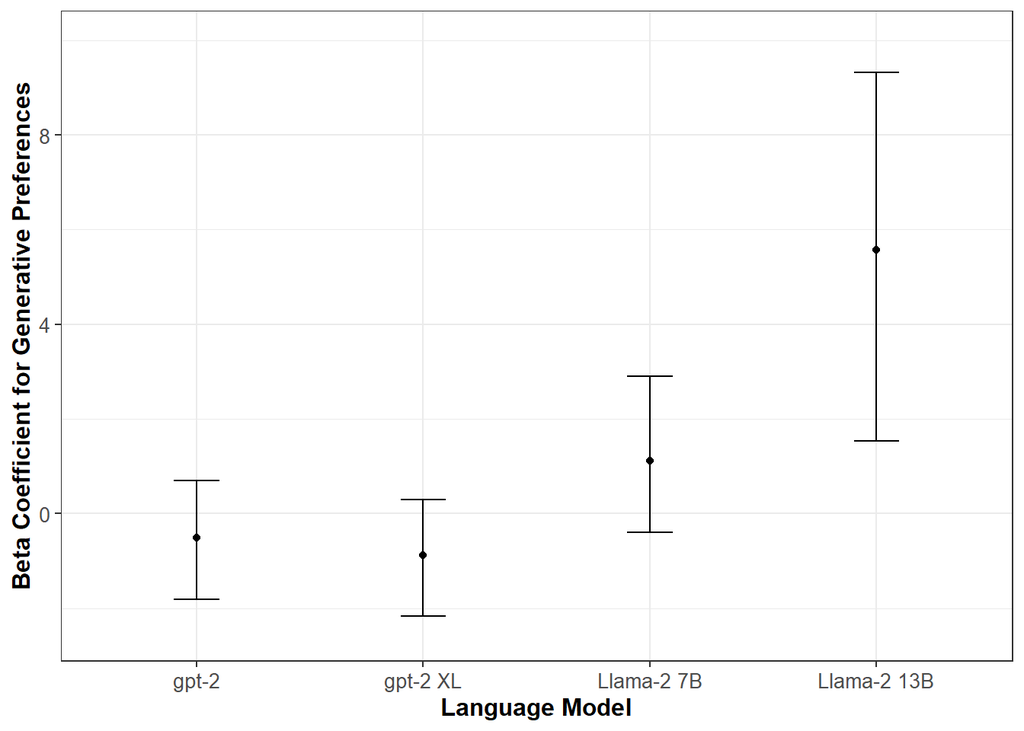

```r
gen_pref_plot_data = all_models_data %>%
  filter(`Beta Coefficient` == 'GenPref')

observed_pref_plot_data = all_models_data %>%
  filter(`Beta Coefficient` == 'RelFreq')

gen_pref_plot_data$model = factor(gen_pref_plot_data$model, levels = c('gpt-2', 'gpt-2 XL', 'Llama-2 7B', 'Llama-2 13B'))

observed_pref_plot_data$model = factor(observed_pref_plot_data$model, levels = c('gpt-2', 'gpt-2 XL', 'Llama-2 7B', 'Llama-2 13B'))

gen_pref_plot = ggplot(data = gen_pref_plot_data, aes(x = model, y = Estimate, ymin = Q2.5, ymax = Q97.5)) +
  geom_errorbar(width = 0.2) +
  geom_point(size = 1.5) +
  theme_bw() +
  theme(axis.text=element_text(size=10),
        axis.title=element_text(size=12,face="bold")) +
  ylim(c(-2.5, 10)) +
  ylab('Beta Coefficient for Generative Preferences') +
  xlab('Language Model')


observed_pref_plot = ggplot(data = observed_pref_plot_data, aes(x = model, y = Estimate, ymin = Q2.5, ymax = Q97.5)) +
  geom_errorbar(width = 0.2) +
  geom_point(size = 1.5) +
  theme_bw() +
  theme(axis.text=element_text(size=10),
        axis.title=element_text(size=12,face="bold")) +
  ylim(c(-2.5, 10)) +
  ylab('Beta Coefficient for Observed Preferences') +
  xlab('Language Model')


gen_pref_plot
```

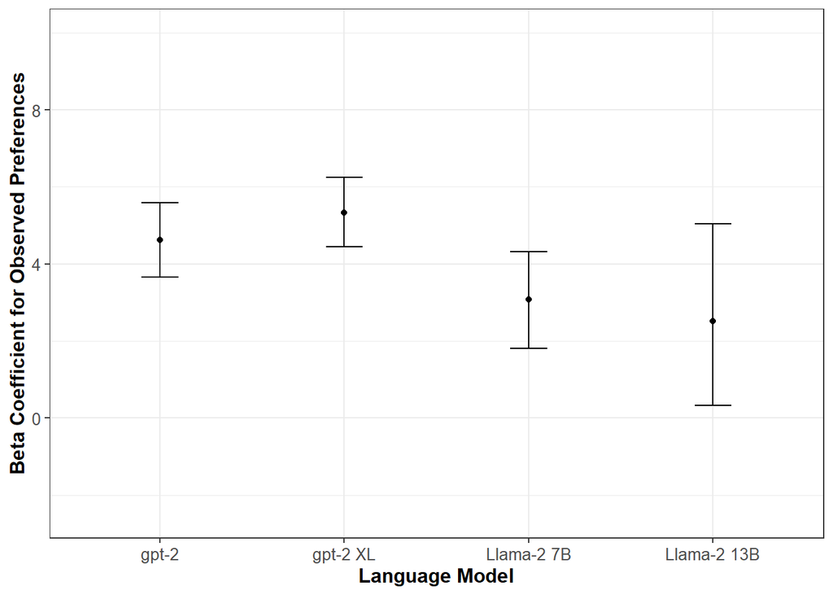

```r
#ggsave('../Data/gen_pref_plot.png')
observed_pref_plot
```

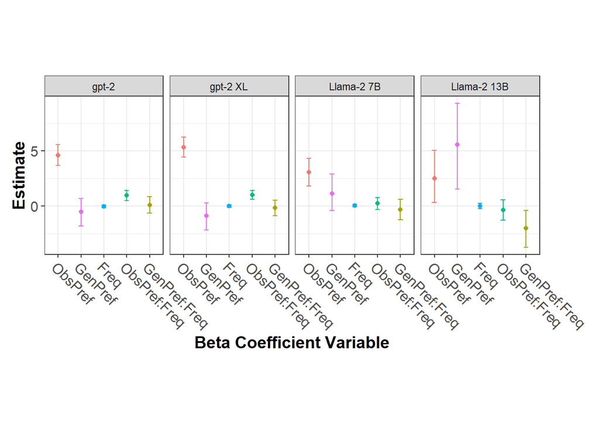

```r
#ggsave('../Data/observed_pref_plot.png')


full_plot_data = all_models_data %>%
  filter(`Beta Coefficient` != 'Intercept') %>%
  mutate(color = ifelse( `Beta Coefficient` == 'GenPref', 'red', ifelse(`Beta Coefficient` == 'RelFreq', 'blue', ifelse(`Beta Coefficient` == 'OverallFreq', 'purple', ifelse(`Beta Coefficient` == 'GenPref:OverallFreq', 'darkgreen', 'orange')))))


full_plot_data$model = factor(full_plot_data$model, levels = c('gpt-2', 'gpt-2 XL', 'Llama-2 7B', 'Llama-2 13B'))

full_plot_data$`Beta Coefficient` = factor(full_plot_data$`Beta Coefficient`, levels = c('RelFreq', 'GenPref', 'OverallFreq', 'RelFreq:OverallFreq', 'GenPref:OverallFreq'))

full_plot = ggplot(data = full_plot_data, aes(x = `Beta Coefficient`, y = Estimate, ymin = Q2.5, ymax = Q97.5, color = color)) +
  geom_errorbar(width = 0.2) +
  geom_point(size = 1.5) +
  facet_wrap(~model, nrow = 1) +
  theme_bw() +
  theme(axis.text=element_text(size=12),
        axis.title=element_text(size=14,face="bold"),
        axis.text.x = element_text(hjust = 0, angle = -45),
        legend.position = 'none',
        plot.margin = margin(10, 50, 10, 10),
        aspect.ratio = 2/1.5
        ) +
  scale_x_discrete(labels = c(expression('ObsPref'), expression('GenPref'), expression('Freq'), expression('ObsPref:Freq'), expression('GenPref:Freq'))) +
 # ylim(c(-2.5, 10)) +
  ylab('Estimate') +
  xlab('Beta Coefficient Variable')

full_plot
```

```r
#ggsave('../Data/full_plot.png')
```

### Reweighting generative preferences

One possibility is that LLMs have learned to weight the generative constraints differently than humans. In this section, we re-weight the generative preferences per LLM preferences, and then run another set of models with the updated generative constraints.

#### Re-weighted constraints

##### GPT2

```r
options(contrasts = c("contr.sum","contr.sum"))


prior_probs = c(
  prior(student_t(3, 0, 1), class = 'Intercept'),
  #prior(student_t(3, 0, 1), class = 'sigma'),
  prior(student_t(3, 0, 1), class = 'b')
)

gpt2_data_just_binoms = gpt2_data_just_binoms %>%
  rename('Stress' = `*BStress`) %>%
  # mutate_each_(funs(factor(.)), c('Form', 'Percept', 'Culture', 'Power', 'Intense', 'Icon', 'Len', 'Lapse', 'Stress')) %>%
  mutate(AlphaPref = ifelse(`Alpha Probs` > `Nonalpha Probs`, 1, 0))

reweighted_model_gpt = brm(data = gpt2_data_just_binoms,
                       AlphaPref ~ Form + Percept + Power + Icon + Len + `Stress` + Freq,
                       family = bernoulli(link = 'logit'),
                       #prior = prior_probs,
                       iter = 10000,
                       warmup = 5000,
                       chains = 4,
                       cores = 4,
                       control = list(adapt_delta=0.99, max_treedepth = 15),
                       prior = prior_probs,
                       #control = list(max_treedepth = 20),
                       file = '../Data/gpt2_reweighted_constraints'
                      )

fixef(reweighted_model_gpt)
```

```
##              Estimate  Est.Error        Q2.5     Q97.5
## Intercept  0.03712050 0.08462405 -0.12879980 0.2022068
## Form      -0.08568561 0.27375592 -0.61911063 0.4517924
## Percept    0.17756813 0.14853431 -0.11090893 0.4691871
## Power      0.25421339 0.22607685 -0.18664472 0.6967975
## Icon       1.15857211 0.27326093  0.64249388 1.7171313
## Len        0.14655730 0.11060523 -0.07039948 0.3646867
## Stress    -0.07483135 0.17348760 -0.41315229 0.2649201
## Freq       0.08094181 0.05530516 -0.02677115 0.1897931
```

##### GPT2-XL

```r
options(contrasts = c("contr.sum","contr.sum"))

gpt2xl_data_just_binoms = gpt2xl_data_just_binoms %>%
  rename('Stress' = `*BStress`) %>%
  # mutate_each_(funs(factor(.)), c('Form', 'Percept', 'Culture', 'Power', 'Intense', 'Icon', 'Len', 'Lapse', 'Stress')) %>%
  mutate(AlphaPref = ifelse(`Alpha Probs` > `Nonalpha Probs`, 1, 0))

reweighted_model_gptxl = brm(data = gpt2xl_data_just_binoms,
                       AlphaPref ~ Form + Percept + Power + Icon + Len + `Stress` + Freq,
                       family = bernoulli(link = 'logit'),
                       #prior = prior_probs,
                       iter = 10000,
                       warmup = 5000,
                       chains = 4,
                       cores = 4,
                       control = list(adapt_delta=0.99, max_treedepth = 15),
                       prior = prior_probs,
                       #control = list(max_treedepth = 20),
                       file = '../Data/gpt2xl_reweighted_constraints'
                      )

fixef(reweighted_model_gptxl)
```

```
##               Estimate  Est.Error        Q2.5     Q97.5
## Intercept  0.142104371 0.08459926 -0.02278065 0.3099408
## Form      -0.137031725 0.27445709 -0.67211722 0.3937956
## Percept    0.211947565 0.15032439 -0.08253248 0.5097301
## Power      0.267708210 0.22718814 -0.17647000 0.7227910
## Icon       0.746455173 0.24513828  0.27770122 1.2370469
## Len        0.161383359 0.10932200 -0.05175287 0.3765143
## Stress     0.120223444 0.17233809 -0.21703922 0.4560770
## Freq       0.009509782 0.05482473 -0.09742966 0.1162495
```

##### Llama-7b

```r
options(contrasts = c("contr.sum","contr.sum"))

llama7b_data_just_binoms = llama7b_data_just_binoms %>%
  rename('Stress' = `*BStress`) %>%
  # mutate_each_(funs(factor(.)), c('Form', 'Percept', 'Culture', 'Power', 'Intense', 'Icon', 'Len', 'Lapse', 'Stress')) %>%
  mutate(AlphaPref = ifelse(`Alpha Probs` > `Nonalpha Probs`, 1, 0))

reweighted_model_llama7b = brm(data = llama7b_data_just_binoms,
                       AlphaPref ~ Form + Percept + Power + Icon + Len + `Stress` + Freq,
                       family = bernoulli(link = 'logit'),
                       #prior = prior_probs,
                       iter = 10000,
                       warmup = 5000,
                       chains = 4,
                       cores = 4,
                       control = list(adapt_delta=0.99, max_treedepth = 15),
                       #control = list(max_treedepth = 20),
                       prior = prior_probs,
                       file = '../Data/llama7b_reweighted_constraints'
                      )

fixef(reweighted_model_llama7b)
```

```
##              Estimate  Est.Error        Q2.5     Q97.5
## Intercept  0.18571271 0.08594378  0.01770769 0.3545272
## Form      -0.08490773 0.27759752 -0.63477658 0.4607015
## Percept    0.24172169 0.15292378 -0.05522248 0.5403637
## Power      0.37160425 0.23245012 -0.07992515 0.8325123
## Icon       0.09536021 0.23480243 -0.36184388 0.5571017
## Len        0.06762551 0.11185652 -0.15167414 0.2893631
## Stress    -0.04553734 0.17616525 -0.39525767 0.2962726
## Freq       0.30507012 0.05902890  0.19259966 0.4247123
```

##### Llama-13b

```r
options(contrasts = c("contr.sum","contr.sum"))

llama13b_data_just_binoms = llama13b_data_just_binoms %>%
  rename('Stress' = `*BStress`) %>%
  # mutate_each_(funs(factor(.)), c('Form', 'Percept', 'Culture', 'Power', 'Intense', 'Icon', 'Len', 'Lapse', 'Stress')) %>%
  mutate(AlphaPref = ifelse(`Alpha Probs` > `Nonalpha Probs`, 1, 0))


reweighted_model_llama13b = brm(data = llama13b_data_just_binoms,
                       AlphaPref ~ Form + Percept + Power + Icon + Len + `Stress` + Freq,
                       family = bernoulli(link = 'logit'),
                       iter = 10000,
                       warmup = 5000,
                       chains = 4,
                       cores = 4,
                       control = list(adapt_delta=0.99, max_treedepth = 15),
                       #control = list(max_treedepth = 20),
                       prior = prior_probs,
                       file = '../Data/llama13b_reweighted_constraints'
                      )

fixef(reweighted_model_llama13b)
```

```
##              Estimate  Est.Error       Q2.5      Q97.5
## Intercept -0.03087043 0.08740708 -0.2022058 0.13764420
## Form      -0.08422177 0.28646403 -0.6475894 0.48418671
## Percept    0.14240633 0.15572012 -0.1606474 0.45027432
## Power      0.24434996 0.24100410 -0.2137325 0.72243250
## Icon       0.57549267 0.24545298  0.1039766 1.06357289
## Len        0.02056959 0.11645117 -0.2056768 0.24993798
## Stress    -0.31432709 0.18430912 -0.6718264 0.04743026
## Freq       0.23151862 0.05972654  0.1150293 0.35023049
```

#### Humans vs Models

Preparing data:

```r
prior_probs = c(
  prior(student_t(2, 0, 0.5), class = 'Intercept'),
  #prior(student_t(3, 0, 1), class = 'sigma'),
  prior(student_t(2, 0, 0.5), class = 'b'),
  prior(student_t(2, 0, 0.5), class = 'sd')
  #prior(student_t(3, 0, 1), class = 'sigma')
)



human_data = read_csv('../Data/data_2afc.csv') %>% #using the 2afc data from the preprint, will need to cite
  separate(UnorderedBinomial, sep = ',', into = c('WordA', 'WordB'), remove = F) %>%
  mutate(WordA = tolower(WordA), WordB = tolower(WordB)) %>%
  mutate(data_type = 'human') %>%
  rename(Stress = 'FinalStress') %>%
  rename(AlphaPref = 'response')
gpt2_data_just_binoms = gpt2_data_just_binoms %>%
  mutate(data_type = 'llm')
gpt2xl_data_just_binoms = gpt2xl_data_just_binoms %>%
  mutate(data_type = 'llm')
llama7b_data_just_binoms = llama7b_data_just_binoms %>%
  mutate(data_type = 'llm')
llama13b_data_just_binoms = llama13b_data_just_binoms %>%
  mutate(data_type = 'llm')

human_data_gpt2 = human_data %>%
  full_join(gpt2_data_just_binoms, by = c('WordA', 'WordB', 'AlphaPref', 'Len', 'Lapse', 'Stress', 'Freq', 'Form', 'Percept', 'Power', 'Icon', 'Culture', 'Intense', 'data_type')) %>%
  filter(WordA %in% (split(WordA, data_type) %>% reduce(intersect))) %>%
  ungroup() %>%
  group_by(WordA, WordB) %>%
  mutate(Item = cur_group_id()) %>%
  select(-item)

human_data_gpt2xl = human_data %>%
  full_join(gpt2xl_data_just_binoms, by = c('WordA', 'WordB', 'AlphaPref', 'Len', 'Lapse', 'Stress', 'Freq', 'Form', 'Percept', 'Power', 'Icon', 'Culture', 'Intense', 'data_type'))  %>%
  filter(WordA %in% (split(WordA, data_type) %>% reduce(intersect))) %>%
  ungroup() %>%
  group_by(WordA, WordB) %>%
  mutate(Item = cur_group_id()) %>%
  select(-item)

human_data_llama7b = human_data %>%
  full_join(llama7b_data_just_binoms, by = c('WordA', 'WordB', 'AlphaPref', 'Len', 'Lapse', 'Stress', 'Freq', 'Form', 'Percept', 'Power', 'Icon', 'Culture', 'Intense', 'data_type'))  %>%
  filter(WordA %in% (split(WordA, data_type) %>% reduce(intersect))) %>%
  ungroup() %>%
  group_by(WordA, WordB) %>%
  mutate(Item = cur_group_id()) %>%
  select(-item)

human_data_llama13b = human_data %>%
  full_join(llama13b_data_just_binoms, by = c('WordA', 'WordB', 'AlphaPref', 'Len', 'Lapse', 'Stress', 'Freq', 'Form', 'Percept', 'Power', 'Icon', 'Culture', 'Intense', 'data_type'))  %>%
  filter(WordA %in% (split(WordA, data_type) %>% reduce(intersect))) %>%
  ungroup() %>%
  group_by(WordA, WordB) %>%
  mutate(Item = cur_group_id()) %>%
  select(-item)
```

##### Humans

```r
options(contrasts = c("contr.sum","contr.sum"))

human_prefs = brm(data = human_data,
                       AlphaPref ~ (Form + Percept + Power + Icon + Len + `Stress` + Freq) + (1|item) + (1|subj),
                       family = bernoulli(link = 'logit'),
                       #prior = prior_probs,
                       iter = 10000,
                       warmup = 5000,
                       chains = 4,
                       cores = 4,
                       #control = list(max_treedepth = 15),
                       prior = prior_probs,
                       #control = list(max_treedepth = 20),
                       file = '../Data/human_prefs'
                      )

fixef(human_prefs)
```

```
##             Estimate  Est.Error        Q2.5     Q97.5
## Intercept 0.12519495 0.05203066  0.02256945 0.2267861
## Form      0.03807625 0.19346217 -0.34575585 0.4182915
## Percept   0.34181407 0.08773115  0.17051760 0.5124851
## Power     0.32924160 0.13437036  0.06780504 0.5927520
## Icon      0.87505339 0.14015984  0.60204128 1.1512795
## Len       0.22109299 0.07517134  0.07450671 0.3689284
## Stress    0.14959575 0.11443459 -0.07206498 0.3761945
## Freq      0.21429967 0.03715092  0.14083664 0.2876980
```

Quick plot of human vs LLM results:

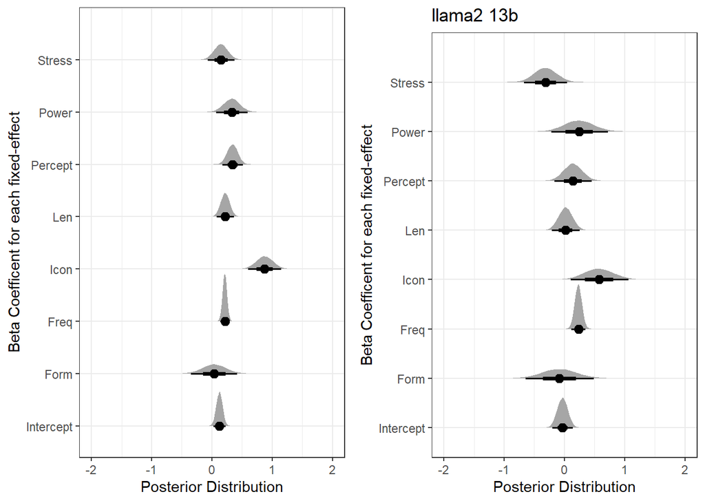

```r
beta_coef_labels = c('Intercept', 'Form', 'Freq', 'Icon', 'Len', 'Percept', 'Power', 'Stress')
levels = c('b_Intercept', 'b_Form', 'b_Freq', 'b_Icon', 'b_Len', 'b_Percept', 'b_Power', 'b_Stress')


human_data_coefs_plot = human_prefs %>%
  gather_draws(b_Intercept, b_Form, b_Percept, b_Power, b_Icon, b_Len, b_Stress, b_Freq) %>%
  ggplot(aes(x = .value, y = factor(.variable, level = levels))) +
  stat_halfeye() +
  xlab('Posterior Distribution') +
  ylab('Beta Coefficent for each fixed-effect') +
  scale_y_discrete(labels = beta_coef_labels) +
  xlim(-2, 2) +
  theme_bw()

reweighted_model_llama13b_plot = reweighted_model_llama13b %>%
  gather_draws(b_Intercept, b_Form, b_Percept, b_Power, b_Icon, b_Len, b_Stress, b_Freq) %>%
  ggplot(aes(x = .value, y = factor(.variable, level = levels))) +
  stat_halfeye() +
  xlab('Posterior Distribution') +
  ylab('Beta Coefficent for each fixed-effect') +
  scale_y_discrete(labels = beta_coef_labels) +
  ggtitle('llama2 13b') +
  xlim(-2, 2) +
  theme_bw()

ggarrange(human_data_coefs_plot, reweighted_model_llama13b_plot, nrow = 1)
```

Human vs GPT-2

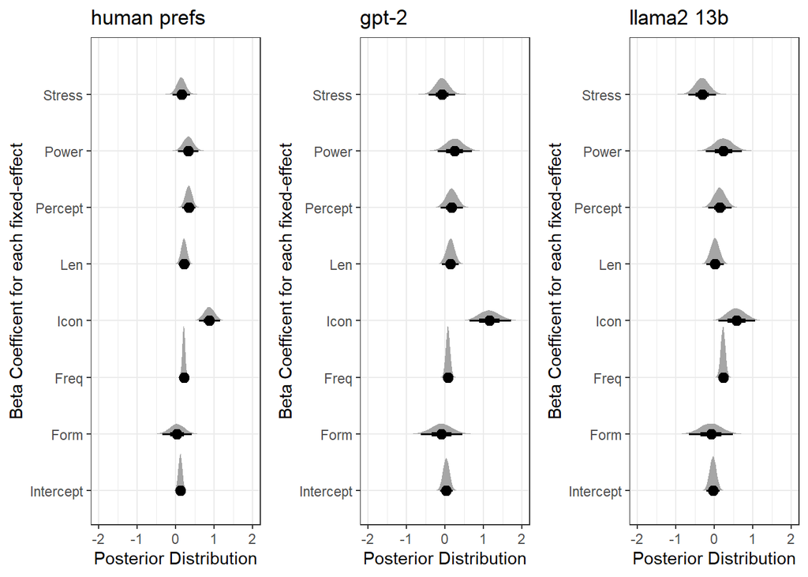

```r
beta_coef_labels = c('Intercept', 'Form', 'Freq', 'Icon', 'Len', 'Percept', 'Power', 'Stress')
levels = c('b_Intercept', 'b_Form', 'b_Freq', 'b_Icon', 'b_Len', 'b_Percept', 'b_Power', 'b_Stress')


human_data_coefs_plot = human_prefs %>%
  gather_draws(b_Intercept, b_Form, b_Percept, b_Power, b_Icon, b_Len, b_Stress, b_Freq) %>%
  ggplot(aes(x = .value, y = factor(.variable, level = levels))) +
  stat_halfeye() +
  xlab('Posterior Distribution') +
  ylab('Beta Coefficent for each fixed-effect') +
  scale_y_discrete(labels = beta_coef_labels) +
  ggtitle('human prefs') +
  xlim(-2, 2) +
  theme_bw()

reweighted_model_gpt2_plot = reweighted_model_gpt %>%
  gather_draws(b_Intercept, b_Form, b_Percept, b_Power, b_Icon, b_Len, b_Stress, b_Freq) %>%
  ggplot(aes(x = .value, y = factor(.variable, level = levels))) +
  stat_halfeye() +
  xlab('Posterior Distribution') +
  ylab('Beta Coefficent for each fixed-effect') +
  scale_y_discrete(labels = beta_coef_labels) +
  ggtitle('gpt-2') +
  xlim(-2, 2) +
  theme_bw()

ggarrange(human_data_coefs_plot, reweighted_model_gpt2_plot, reweighted_model_llama13b_plot, nrow = 1)
```

##### GPT2

```r
# options(contrasts = c("contr.sum","contr.sum"))
#
# human_llm_gpt2 = brm(data = human_data_gpt2,
#                        AlphaPref ~ (Form + Percept + Power + Icon + Len + `Stress` + Freq) * data_type + (1|data_type) + (1|Item),
#                        family = bernoulli(link = 'logit'),
#                        #prior = prior_probs,
#                        iter = 10000,
#                        warmup = 5000,
#                        chains = 4,
#                        cores = 4,
#                        control = list(max_treedepth = 15),
#                        prior = prior_probs,
#                        #control = list(max_treedepth = 20),
#                        file = '../Data/human_llm_gpt2'
#                       )
#
# fixef(human_llm_gpt2)
```

##### GPT2-XL

```r
# options(contrasts = c("contr.sum","contr.sum"))
#
# human_llm_gpt2xl = brm(data = human_data_gpt2xl,
#                        AlphaPref ~ (Form + Percept + Power + Icon + Len + `Stress` + Freq) * data_type + (1 + Item|data_type) + (1|Item),
#                        family = bernoulli(link = 'logit'),
#                        #prior = prior_probs,
#                        iter = 10000,
#                        warmup = 5000,
#                        chains = 4,
#                        cores = 4,
#                        #control = list(adapt_delta=0.99, max_treedepth = 15),
#                        prior = prior_probs,
#                        #control = list(max_treedepth = 20),
#                        file = '../Data/human_llm_gpt2xl'
#                       )
#
# fixef(human_llm_gpt2xl)
```

##### Llama-7b

```r
# options(contrasts = c("contr.sum","contr.sum"))
#
# human_llm_llama7b = brm(data = human_data_llama7b,
#                        AlphaPref ~ (Form + Percept + Power + Icon + Len + `Stress` + Freq) * data_type + (1 + Item|data_type) + (1|Item),
#                        family = bernoulli(link = 'logit'),
#                        #prior = prior_probs,
#                        iter = 10000,
#                        warmup = 5000,
#                        chains = 4,
#                        cores = 4,
#                        #control = list(adapt_delta=0.99, max_treedepth = 15),
#                        prior = prior_probs,
#                        #control = list(max_treedepth = 20),
#                        file = '../Data/human_llm_llama7b'
#                       )
#
# fixef(human_llm_llama7b)
```

##### Llama-13b

```r
# options(contrasts = c("contr.sum","contr.sum"))
#
# human_llm_llama13b = brm(data = human_data_llama13b,
#                        AlphaPref ~ (Form + Percept + Power + Icon + Len + `Stress` + Freq) * data_type+ (1|data_type),# + (1 + Item||data_type) + (1||Item),
#                        family = bernoulli(link = 'logit'),
#                        #prior = prior_probs,
#                        iter = 10000,
#                        warmup = 5000,
#                        chains = 4,
#                        cores = 4,
#                        #control = list(adapt_delta=0.99, max_treedepth = 15),
#                        prior = prior_probs,
#                        #control = list(max_treedepth = 15),
#                        file = '../Data/human_llm_llama13b'
#                       )
#
# fixef(human_llm_llama13b)
#
#
# mcmc_plot(human_llm_llama13b, type = 'trace')
#mcmc_plot(reweighted_model_llama13b, type = 'dens')
```

## Olmo Models

### 1B Model

#### Step20000 - 86B tokens

```python
#from huggingface_hub import list_repo_refs

#out = list_repo_refs("allenai/OLMo-7B")
#branches = [b.name for b in out.branches]
```

```r
olmo1b_20000_86B = read_csv('../Data/olmo1b_step20000_tokens84B.csv') %>%
  separate(binom, c('WordA', 'and', 'WordB'), remove = F, sep = ' ') %>%
  select(-and) %>%
  mutate(across(2:3, tolower)) %>%
  left_join(corpus) %>%
  mutate(log_freq = log(OverallFreq)) %>%
  mutate(OverallFreq = log_freq - mean(log_freq)) %>%
  mutate(GenPref = GenPref - 0.5) %>%
  mutate(RelFreq = RelFreq - 0.5)
prior_probs = c(
  prior(student_t(3, 0, 1), class = 'Intercept'),
  prior(student_t(3, 0, 1), class = 'sigma'),
  prior(student_t(3, 0, 1), class = 'b')
)

options(contrasts = c("contr.sum","contr.sum"))

olmo1b_20000_86B_model = brm(data = olmo1b_20000_86B,
                       log_odds ~ GenPref + RelFreq + GenPref:OverallFreq + RelFreq:OverallFreq + OverallFreq,
                       prior = prior_probs,
                       iter = 10000,
                       warmup = 5000,
                       chains = 4,
                       cores = 4,
                       #control = list(adapt_delta=0.99, max_treedepth = 15),
                       #control = list(max_treedepth = 20),
                       file = '../Data/olmo1b_20000_86B'
                      )

fixef(olmo1b_20000_86B_model)
```

```
##                        Estimate Est.Error        Q2.5     Q97.5
## Intercept            0.05160866 0.1129368 -0.16924937 0.2737135
## GenPref             -0.74617547 0.7257369 -2.23429688 0.6192938
## RelFreq              4.15491059 0.5653127  3.05425183 5.2727580
## OverallFreq          0.08321975 0.0609865 -0.03498637 0.2025660
## GenPref:OverallFreq  0.66588133 0.4355545 -0.17082335 1.5253380
## RelFreq:OverallFreq  0.66290921 0.2637851  0.15327074 1.1830277
```

#### Step30000 - 126B Tokens

```r
olmo1b_30000_126B = read_csv('../Data/olmo1b_step30000_tokens126B.csv') %>%
  separate(binom, c('WordA', 'and', 'WordB'), remove = F, sep = ' ') %>%
  select(-and) %>%
  mutate(across(2:3, tolower)) %>%
  left_join(corpus) %>%
  mutate(log_freq = log(OverallFreq)) %>%
  mutate(OverallFreq = log_freq - mean(log_freq)) %>%
  mutate(GenPref = GenPref - 0.5) %>%
  mutate(RelFreq = RelFreq - 0.5)
prior_probs = c(
  prior(student_t(3, 0, 1), class = 'Intercept'),
  prior(student_t(3, 0, 1), class = 'sigma'),
  prior(student_t(3, 0, 1), class = 'b')
)

options(contrasts = c("contr.sum","contr.sum"))

olmo1b_30000_126B_model = brm(data = olmo1b_30000_126B,
                       log_odds ~ GenPref + RelFreq + GenPref:OverallFreq + RelFreq:OverallFreq + OverallFreq,
                       prior = prior_probs,
                       iter = 10000,
                       warmup = 5000,
                       chains = 4,
                       cores = 4,
                       #control = list(adapt_delta=0.99, max_treedepth = 15),
                       control = list(max_treedepth = 20),
                       file = '../Data/olmo1b_30000_126B'
                      )

fixef(olmo1b_30000_126B_model)
```

```
##                        Estimate  Est.Error       Q2.5      Q97.5
## Intercept            0.06847938 0.09781745 -0.1232519 0.25747178
## GenPref             -0.73173146 0.65073437 -2.0818801 0.49990900
## RelFreq              4.45863351 0.49398630  3.5009108 5.43402566
## OverallFreq         -0.01067736 0.05310245 -0.1156564 0.09232893
## GenPref:OverallFreq  0.19796256 0.37820975 -0.5352908 0.93598611
## RelFreq:OverallFreq  0.78575744 0.22999341  0.3386810 1.23993637
```

#### Step 4000 168B Tokens

```r
olmo1b_40000_168B = read_csv('../Data/olmo1b_step40000_tokens168B.csv') %>%
  separate(binom, c('WordA', 'and', 'WordB'), remove = F, sep = ' ') %>%
  select(-and) %>%
  mutate(across(2:3, tolower)) %>%
  left_join(corpus) %>%
  mutate(log_freq = log(OverallFreq)) %>%
  mutate(OverallFreq = log_freq - mean(log_freq)) %>%
  mutate(GenPref = GenPref - 0.5) %>%
  mutate(RelFreq = RelFreq - 0.5)
prior_probs = c(
  prior(student_t(3, 0, 1), class = 'Intercept'),
  prior(student_t(3, 0, 1), class = 'sigma'),
  prior(student_t(3, 0, 1), class = 'b')
)

options(contrasts = c("contr.sum","contr.sum"))

olmo1b_40000_168B_model = brm(data = olmo1b_40000_168B,
                       log_odds ~ GenPref + RelFreq + GenPref:OverallFreq + RelFreq:OverallFreq + OverallFreq,
                       prior = prior_probs,
                       iter = 10000,
                       warmup = 5000,
                       chains = 4,
                       cores = 4,
                       #control = list(adapt_delta=0.99, max_treedepth = 15),
                       control = list(max_treedepth = 20),
                       file = '../Data/olmo1b_40000_168B'
                      )

fixef(olmo1b_40000_168B_model)
```

```
##                          Estimate  Est.Error        Q2.5     Q97.5
## Intercept            0.0936978251 0.09704929 -0.09453828 0.2846078
## GenPref             -0.1797905715 0.61323660 -1.40339992 1.0331624
## RelFreq              4.4002373603 0.47741162  3.46436110 5.3452676
## OverallFreq         -0.0006541446 0.05292785 -0.10571193 0.1036748
## GenPref:OverallFreq -0.1650735379 0.37481401 -0.90504445 0.5732261
## RelFreq:OverallFreq  0.9379873755 0.23070715  0.48796323 1.3942889
```

#### Full Model

```r
olmo1b_main = read_csv('../Data/olmo1b_main.csv') %>%
  separate(binom, c('WordA', 'and', 'WordB'), remove = F, sep = ' ') %>%
  select(-and) %>%
  mutate(across(2:3, tolower)) %>%
  left_join(corpus) %>%
  mutate(log_freq = log(OverallFreq)) %>%
  mutate(OverallFreq = log_freq - mean(log_freq)) %>%
  mutate(GenPref = GenPref - 0.5) %>%
  mutate(RelFreq = RelFreq - 0.5)
prior_probs = c(
  prior(student_t(3, 0, 1), class = 'Intercept'),
  prior(student_t(3, 0, 1), class = 'sigma'),
  prior(student_t(3, 0, 1), class = 'b')
)

options(contrasts = c("contr.sum","contr.sum"))

olmo1b_main_model = brm(data = olmo1b_main,
                       log_odds ~ GenPref + RelFreq + GenPref:OverallFreq + RelFreq:OverallFreq + OverallFreq,
                       prior = prior_probs,
                       iter = 10000,
                       warmup = 5000,
                       chains = 4,
                       cores = 4,
                       #control = list(adapt_delta=0.99, max_treedepth = 15),
                       control = list(max_treedepth = 20),
                       file = '../Data/olmo1b_main'
                      )



fixef(olmo1b_main_model)
```

```
##                        Estimate  Est.Error        Q2.5     Q97.5
## Intercept            0.06276615 0.07827138 -0.09181953 0.2170182
## GenPref              0.68153095 0.54787526 -0.35602685 1.7991149
## RelFreq              4.36697402 0.39323697  3.59179839 5.1421105
## OverallFreq          0.05808252 0.04157354 -0.02317914 0.1389432
## GenPref:OverallFreq -0.12522215 0.31074939 -0.72918437 0.4920970
## RelFreq:OverallFreq  0.80737656 0.18612494  0.44523409 1.1710015
```

```r
post_samples_olmo1b = as.data.frame(fixef(olmo1b_main_model, summary = F))
post_samples_genpref = sum(post_samples_olmo1b$GenPref < 0) / length(post_samples_olmo1b$GenPref)
post_samples_genpref
```

```
## [1] 0.104
```

### 7B Model

#### Step20000 - 84B tokens

```python
#from huggingface_hub import list_repo_refs

#out = list_repo_refs("allenai/OLMo-7B")
#branches = [b.name for b in out.branches]
```

```r
olmo7b_20000_86B = read_csv('../Data/olmo7b_step20000_tokens84B.csv') %>%
  separate(binom, c('WordA', 'and', 'WordB'), remove = F, sep = ' ') %>%
  select(-and) %>%
  mutate(across(2:3, tolower)) %>%
  left_join(corpus) %>%
  mutate(log_freq = log(OverallFreq)) %>%
  mutate(OverallFreq = log_freq - mean(log_freq)) %>%
  mutate(GenPref = GenPref - 0.5) %>%
  mutate(RelFreq = RelFreq - 0.5)
prior_probs = c(
  prior(student_t(3, 0, 1), class = 'Intercept'),
  prior(student_t(3, 0, 1), class = 'sigma'),
  prior(student_t(3, 0, 1), class = 'b')
)

options(contrasts = c("contr.sum","contr.sum"))

olmo7b_20000_86B_model = brm(data = olmo7b_20000_86B,
                       log_odds ~ GenPref + RelFreq + GenPref:OverallFreq + RelFreq:OverallFreq + OverallFreq,
                       prior = prior_probs,
                       iter = 10000,
                       warmup = 5000,
                       chains = 4,
                       cores = 4,
                       #control = list(adapt_delta=0.99, max_treedepth = 15),
                       control = list(max_treedepth = 20),
                       file = '../Data/olmo7b_20000_86B'
                      )

fixef(olmo7b_20000_86B_model)
```

```
##                        Estimate  Est.Error        Q2.5     Q97.5
## Intercept            0.06474281 0.08432215 -0.10047250 0.2303773
## GenPref             -0.07581698 0.55083327 -1.16128404 1.0012197
## RelFreq              5.17830041 0.41986988  4.36065217 6.0023023
## OverallFreq          0.03587552 0.04562275 -0.05306598 0.1258964
## GenPref:OverallFreq  0.24300557 0.33536711 -0.40580731 0.9109038
## RelFreq:OverallFreq  0.82763588 0.20181491  0.42964654 1.2242091
```

#### Step30000 - 126B Tokens

```r
olmo7b_30000_126B = read_csv('../Data/olmo7b_step30000_tokens128B.csv') %>%
  separate(binom, c('WordA', 'and', 'WordB'), remove = F, sep = ' ') %>%
  select(-and) %>%
  mutate(across(2:3, tolower)) %>%
  left_join(corpus) %>%
  mutate(log_freq = log(OverallFreq)) %>%
  mutate(OverallFreq = log_freq - mean(log_freq)) %>%
  mutate(GenPref = GenPref - 0.5) %>%
  mutate(RelFreq = RelFreq - 0.5)
prior_probs = c(
  prior(student_t(3, 0, 1), class = 'Intercept'),
  prior(student_t(3, 0, 1), class = 'sigma'),
  prior(student_t(3, 0, 1), class = 'b')
)

options(contrasts = c("contr.sum","contr.sum"))

olmo7b_30000_126B_model = brm(data = olmo7b_30000_126B,
                       log_odds ~ GenPref + RelFreq + GenPref:OverallFreq + RelFreq:OverallFreq + OverallFreq,
                       prior = prior_probs,
                       iter = 10000,
                       warmup = 5000,
                       chains = 4,
                       cores = 4,
                       #control = list(adapt_delta=0.99, max_treedepth = 15),
                       control = list(max_treedepth = 20),
                       file = '../Data/olmo7b_30000_126B'
                      )

fixef(olmo7b_30000_126B_model)
```

```
##                       Estimate  Est.Error        Q2.5     Q97.5
## Intercept            0.1007800 0.08436903 -0.06442172 0.2638704
## GenPref             -0.4602898 0.55322170 -1.57940714 0.5981450
## RelFreq              5.4501443 0.41587153  4.62987588 6.2707717
## OverallFreq          0.0158879 0.04503649 -0.07273285 0.1049295
## GenPref:OverallFreq -0.3364437 0.33045660 -0.98895668 0.2990358
## RelFreq:OverallFreq  0.8598022 0.20085364  0.46646587 1.2522590
```

#### Step 40000 168B Tokens

```r
olmo7b_40000_168B = read_csv('../Data/olmo7b_step40000_tokens168B.csv') %>%
  separate(binom, c('WordA', 'and', 'WordB'), remove = F, sep = ' ') %>%
  select(-and) %>%
  mutate(across(2:3, tolower)) %>%
  left_join(corpus) %>%
  mutate(log_freq = log(OverallFreq)) %>%
  mutate(OverallFreq = log_freq - mean(log_freq)) %>%
  mutate(GenPref = GenPref - 0.5) %>%
  mutate(RelFreq = RelFreq - 0.5)
prior_probs = c(
  prior(student_t(3, 0, 1), class = 'Intercept'),
  prior(student_t(3, 0, 1), class = 'sigma'),
  prior(student_t(3, 0, 1), class = 'b')
)

options(contrasts = c("contr.sum","contr.sum"))

olmo7b_40000_168B_model = brm(data = olmo1b_40000_168B,
                       log_odds ~ GenPref + RelFreq + GenPref:OverallFreq + RelFreq:OverallFreq + OverallFreq,
                       prior = prior_probs,
                       iter = 10000,
                       warmup = 5000,
                       chains = 4,
                       cores = 4,
                       #control = list(adapt_delta=0.99, max_treedepth = 15),
                       control = list(max_treedepth = 20),
                       file = '../Data/olmo7b_40000_168B'
                      )

fixef(olmo7b_40000_168B_model)
```

```
##                          Estimate  Est.Error        Q2.5     Q97.5
## Intercept            0.0944177929 0.09692613 -0.09497537 0.2843205
## GenPref             -0.1679471495 0.61705505 -1.42397747 1.0301012
## RelFreq              4.3963231659 0.48436770  3.44311859 5.3612888
## OverallFreq         -0.0003366194 0.05207166 -0.10251123 0.1033776
## GenPref:OverallFreq -0.1665940018 0.38116205 -0.91181892 0.5815627
## RelFreq:OverallFreq  0.9401419611 0.23257594  0.48546735 1.4008355
```

#### Full Model

```r
olmo7b_main = read_csv('../Data/olmo7b_main.csv') %>%
  separate(binom, c('WordA', 'and', 'WordB'), remove = F, sep = ' ') %>%
  select(-and) %>%
  mutate(across(2:3, tolower)) %>%
  left_join(corpus) %>%
  mutate(log_freq = log(OverallFreq)) %>%
  mutate(OverallFreq = log_freq - mean(log_freq)) %>%
  mutate(GenPref = GenPref - 0.5) %>%
  mutate(RelFreq = RelFreq - 0.5)
prior_probs = c(
  prior(student_t(3, 0, 1), class = 'Intercept'),
  prior(student_t(3, 0, 1), class = 'sigma'),
  prior(student_t(3, 0, 1), class = 'b')
)

options(contrasts = c("contr.sum","contr.sum"))

olmo7b_main_model = brm(data = olmo7b_main,
                       log_odds ~ GenPref + RelFreq + GenPref:OverallFreq + RelFreq:OverallFreq + OverallFreq,
                       prior = prior_probs,
                       iter = 10000,
                       warmup = 5000,
                       chains = 4,
                       cores = 4,
                       #control = list(adapt_delta=0.99, max_treedepth = 15),
                       control = list(max_treedepth = 20),
                       file = '../Data/olmo7b_main'
                      )

fixef(olmo7b_main_model)
```

```
##                         Estimate  Est.Error        Q2.5      Q97.5
## Intercept            0.042930584 0.07120502 -0.09534298 0.17972678
## GenPref             -0.853869864 0.51231683 -1.89353960 0.12918836
## RelFreq              5.369617013 0.36536411  4.65639389 6.08578403
## OverallFreq          0.005025558 0.03796894 -0.06931977 0.07959481
## GenPref:OverallFreq  0.098711038 0.28700915 -0.45912913 0.66320720
## RelFreq:OverallFreq  0.699896419 0.17153142  0.36429922 1.03748599
```

```r
post_samples_olmo7b = as.data.frame(fixef(olmo7b_main_model, summary = F))

post_samples_genpref = sum(post_samples_olmo7b$GenPref < 0) / length(post_samples_olmo7b$GenPref)
post_samples_genpref
```

```
## [1] 0.95515
```